# PA1_template

Lau Laustsen

17 okt 2018

## Abstract

In this document a data analysis and the coding behind is communicated and documented. The data is from personal activity monitoring devices such as a Fitbit, Nike Fuelband, or Jawbone Up. The datasample consists of two months of data from an anonymous individual collected during the months of October and November, 2012 and include the number of steps taken in 5 minute intervals each day. Below data i explored and graphs are produced. This is done using R-markdown and knit toobox. As part of the assignment a gihub reposity https://github.com/rdpeng/RepData_PeerAssessment1 is forked/cloned and this script is pushed, and thereby shared.

Sourcedata Description

The variables included in the dataset are: - steps: Number of steps taking in a 5-minute interval (missing values are coded as NA - date: The date on which the measurement was taken in YYYY-MM-DD format - interval: Identifier for the 5-minute interval in which measurement was taken

### 1. Code for reading in the dataset and/or processing the data

```r
##Set working directory
 setwd("C:/Docs/Uddannelse/Coursera/Datascience/5Reproducible/Assignment1")

## Read csv-file
 activity <- read.csv("activity.csv", header = TRUE,
             sep = ',',colClasses = c("numeric", "character","integer"))

## Convert date strings to date objects
 activity$date <- as.Date(activity$date)
 #activity$date <- as.POSIXct(activity$date)
 #activity$date <- ymd(activity$date)

## Describe
 str(activity)
```

```
## 'data.frame':    17568 obs. of  3 variables:
##  $ steps   : num  NA NA NA NA NA NA NA NA NA NA ...
##  $ date    : Date, format: "2012-10-01" "2012-10-01" ...
##  $ interval: int  0 5 10 15 20 25 30 35 40 45 ...
```

### 2. Histogram of the total number of steps taken each day

dplyr, plyr and knitr packages are installed

```r
## Group steps per day (dplyr)
stepsperday <- tbl_df(activity) %>%
    filter(!is.na(steps)) %>%
    group_by(date) %>%
    summarise(Steps=sum(steps)) %>%
    print
```

```
## # A tibble: 53 x 2
##    date       Steps
##    <date>     <dbl>
##  1 2012-10-02   126
##  2 2012-10-03 11352
##  3 2012-10-04 12116
##  4 2012-10-05 13294
##  5 2012-10-06 15420
##  6 2012-10-07 11015
##  7 2012-10-09 12811
##  8 2012-10-10  9900
##  9 2012-10-11 10304
## 10 2012-10-12 17382
## # ... with 43 more rows
```

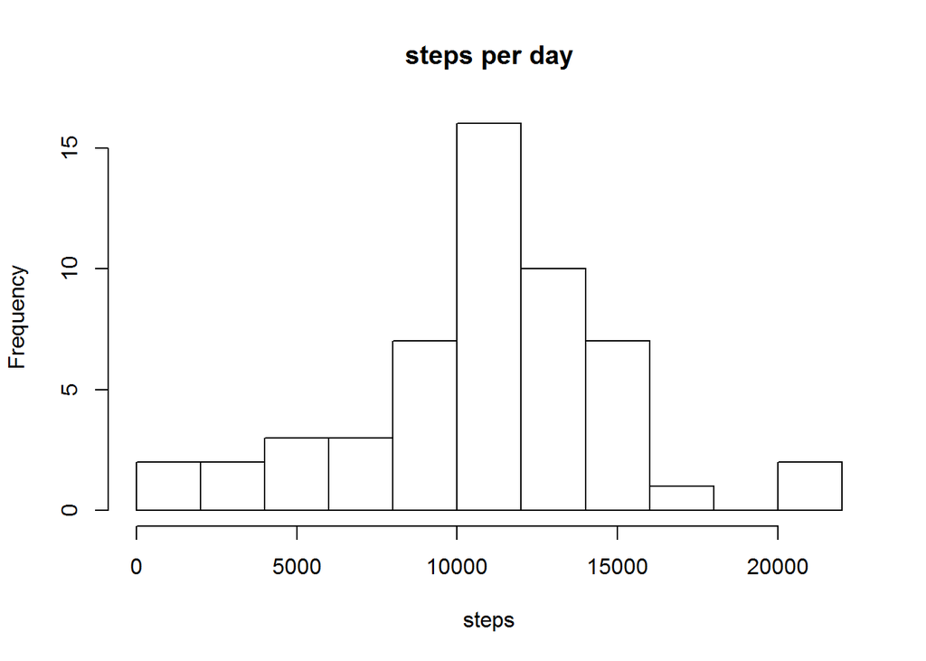

```r
#stepsperday <- aggregate(steps~date,activity,sum)

##Historgram
with(stepsperday,hist(Steps,xlab="steps",main="steps per day",breaks = 10))
```

```r
stepsmean <- mean(stepsperday$Steps)
stepsmedian <- median(stepsperday$Steps)
```

### 4. Time series plot of the average number of steps taken

The average number of steps per day

```r
avgstepsperday <- tbl_df(activity) %>%
    filter(!is.na(steps)) %>%
    group_by(interval) %>%
    summarise(avgSteps=mean(steps), minSteps=min(steps), maxSteps=max(steps)) %>%
    print
```

```
## # A tibble: 288 x 4
##    interval avgSteps minSteps maxSteps
##       <int>    <dbl>    <dbl>    <dbl>
##  1        0   1.72          0       47
##  2        5   0.340         0       18
##  3       10   0.132         0        7
##  4       15   0.151         0        8
##  5       20   0.0755        0        4
##  6       25   2.09          0       52
##  7       30   0.528         0       28
##  8       35   0.868         0       46
##  9       40   0             0        0
## 10       45   1.47          0       72
## # ... with 278 more rows
```

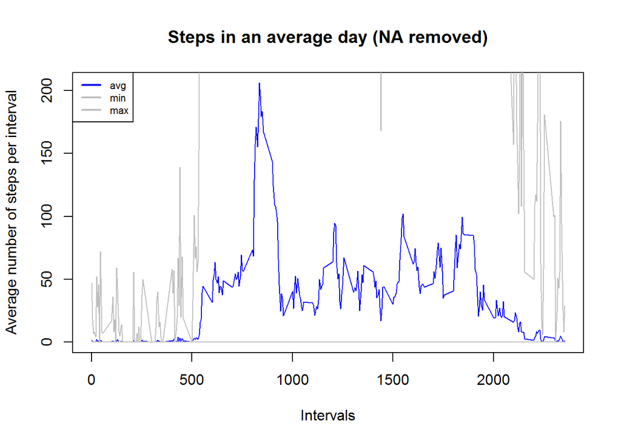

```r
with(avgstepsperday,{
     plot(interval, avgSteps, col='blue', type = "l", xlab = "Intervals",
     ylab = "Average number of steps per interval",
     main = "Steps in an average day (NA removed)")
     lines(interval, minSteps, col='grey')
     lines(interval, maxSteps, col='grey')
     legend("topleft",legend= c("avg","min", "max"), lwd=2, cex=0.7, col=c("blue", "grey", "grey"))
     })
```

```r
val<-max(avgstepsperday$avgSteps)
idx<- round(which(avgstepsperday$avgSteps==val))
idx_hour<-idx %/% 12
#idx %% 12
```

### 6. Code to describe and show a strategy for imputing missing data

```r
num<-sum(is.na(activity$steps))
share <- round(num/dim(activity)[1]*100,1)
```

The number of missing values are 2304 which corresponds too 13.1 %. The missing values in the respective interval could be subsidized by the average number of steps i the same interval. This is done by creating an index (idx) for missing values in original dataset. Thereafter the vector indicating the average number of steps in intervals (length 288) are replicate 61 times (days) to match original dataset (length 17568). Finally the index for missing values is used as a map for overwrittng missing values.

```r
#str(avgstepsperday$avgSteps)
#str(activity2)

activity2 <- activity
idx <-is.na(activity)

activity2[idx,1] <- rep(avgstepsperday$avgSteps,times=dim(activity)[1]/288)[idx]
nmv<-sum(is.na(activity2$steps))
str(activity2)
```

```
## 'data.frame':    17568 obs. of  3 variables:
##  $ steps   : num  1.717 0.3396 0.1321 0.1509 0.0755 ...
##  $ date    : Date, format: "2012-10-01" "2012-10-01" ...
##  $ interval: int  0 5 10 15 20 25 30 35 40 45 ...
```

In new dataset there are 0 missing values.

### 7. Histogram of the total number of steps taken each day after missing values are imputed

Group steps per day (dplyr)

```r
stepsperday2 <- tbl_df(activity2) %>%
    filter(!is.na(steps)) %>%
    group_by(date) %>%
    summarise(Steps=sum(steps)) %>%
    print
```

```
## # A tibble: 61 x 2
##    date        Steps
##    <date>      <dbl>
##  1 2012-10-01 10766.
##  2 2012-10-02   126
##  3 2012-10-03 11352
##  4 2012-10-04 12116
##  5 2012-10-05 13294
##  6 2012-10-06 15420
##  7 2012-10-07 11015
##  8 2012-10-08 10766.
##  9 2012-10-09 12811
## 10 2012-10-10  9900
## # ... with 51 more rows
```

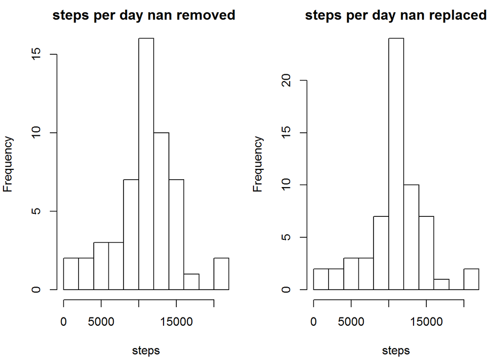

```r
par(mfrow = c(1,2), mar = c(4, 4, 2, 1))
    #par "set" graphical parameters! her
    # mfrow der laver en 2x1 subfigure
    # mar   der bestemmer figurens størrelse [bot,left,top,right]
    #       som matlab set('position',[2 3 4 1])
with(stepsperday ,hist(Steps,xlab="steps",main="steps per day nan removed ",breaks = 10))
with(stepsperday2,hist(Steps,xlab="steps",main="steps per day nan replaced",breaks = 10))
```

```r
#A vector indicating daytype
activity$day  <- weekdays(activity$date, abbreviate = TRUE)
activity$daytype <- ifelse(activity$day == "lø" | activity$day == "sø","weekend","weekday")
activity$daytype <- as.factor(activity$daytype)
#str(unique(activity$daytype))
str(activity)
```

```
## 'data.frame':    17568 obs. of  5 variables:
##  $ steps   : num  NA NA NA NA NA NA NA NA NA NA ...
##  $ date    : Date, format: "2012-10-01" "2012-10-01" ...
##  $ interval: int  0 5 10 15 20 25 30 35 40 45 ...
##  $ day     : chr  "Mon" "Mon" "Mon" "Mon" ...
##  $ daytype : Factor w/ 1 level "weekday": 1 1 1 1 1 1 1 1 1 1 ...
```

```r
#Aggregate steps in hours depending on daytype
stepsperday3 <- tbl_df(activity) %>%
    filter(!is.na(steps)) %>%
    group_by(interval,daytype) %>%
    summarise(Steps=mean(steps)) %>%
    print
```

```
## # A tibble: 288 x 3
## # Groups:   interval [?]
##    interval daytype  Steps
##       <int> <fct>    <dbl>
##  1        0 weekday 1.72
##  2        5 weekday 0.340
##  3       10 weekday 0.132
##  4       15 weekday 0.151
##  5       20 weekday 0.0755
##  6       25 weekday 2.09
##  7       30 weekday 0.528
##  8       35 weekday 0.868
##  9       40 weekday 0
## 10       45 weekday 1.47
## # ... with 278 more rows
```

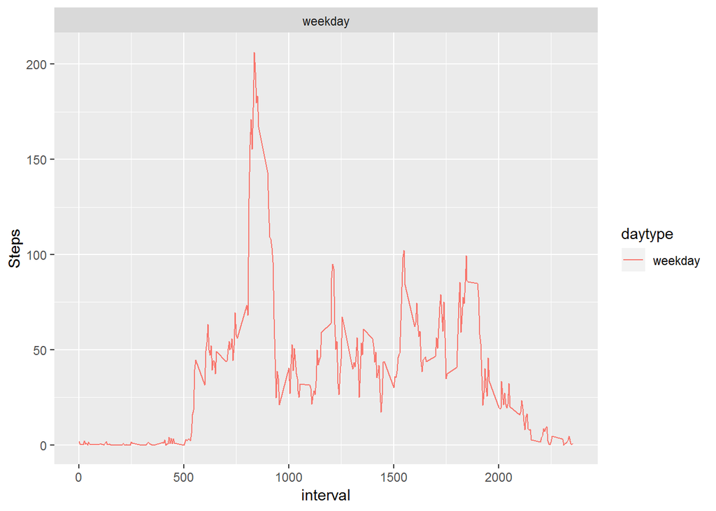

```r
#str(stepsperday3)

#Basic PLot (couldnt be included in markdown report)
# par(mfrow = c(1, 1), mar = c(4, 4, 2, 1), oma = c(0, 0, 2, 0))
# with(subset(stepsperday3,daytype=="weekday"),
#    plot(Steps, main="Mean steps in weekday vs weekend Intervals",
#    type="l",col="blue", cex.main=0.8, cex.lab=0.6, cex.axis=0.6))
# with(subset(stepsperday3,daytype=="weekend"),
#    lines(Steps,xlab="steps",col="red"))
# legend("topright", pch = 1, col = c("blue", "red"),
#    legend = c("weekday", "weekend"), cex=0.75)
#par(new=TRUE) if different axis

#Same figure using (ggplot2)
h <- ggplot(stepsperday3, aes(x=interval, y=Steps, color = daytype)) +
  geom_line() +
  facet_wrap(~daytype, ncol = 2, nrow=1)
print(h)
```